# Limitless Regression Discontinuity

U. Wisconsin Statistics Dept (Nov. 2019)

## Overview of talk

- Three perspectives on the regression discontinuity design (RDD)
- Picking out the (quasi-)experiment within a RDD: concepts & methods
- Managing RDDs’ inevitable imperfections
  - The “donut design”
  - Robustness to contamination of the sample
- \(\Rightarrow\) unusual (to RDD literature) methods. Are the answers any different?

## Three perspectives on the regression discontinuity design

## Academic probation and later grades

### Data from 3 Canadian colleges (Lindo et al 2010)

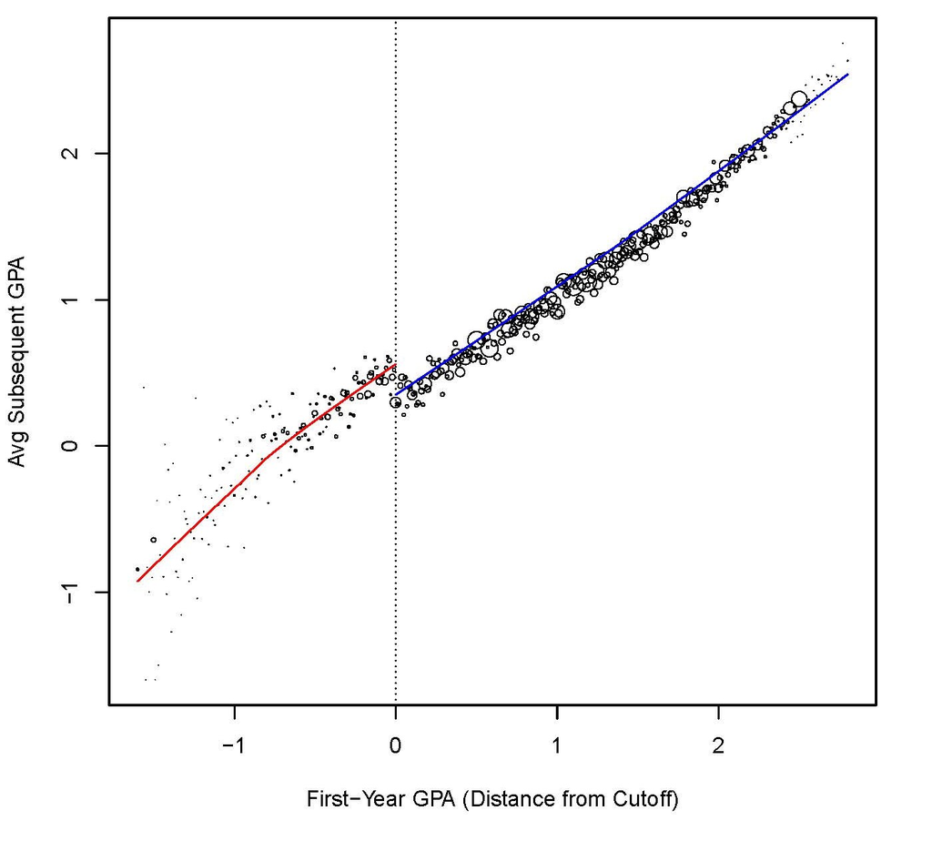

Problem: *net of the running variable* \(R\) (college year 1 grade avg. or GPA), what’s \(Z \equiv \mathcal{I}[R<0]\)’s effect on \(Y\) (year 2 GPA)?

(A *regression discontinuity* estimate of academic probation’s impact.)

## Regression discontinuity designs

### (RDDs): Three causal interpretations

- Traditional view (Thistlethwaite and Campbell 1960): Assume \(Y = \alpha + \tau Z + \beta R + \epsilon\), \(\epsilon \perp R\). The causal effect is \(\tau\).
- Limit-based view (Hahn, Todd, and Klaauw 2001; Imbens and Lemieux 2008): Perhaps \(E(Y|R, Z)\) is linear, perhaps not; causal effect is \(\lim_{r\uparrow 0} E(Y|R=r) - \lim_{r\downarrow 0} E(Y|R=r) =: \tau\).
- Potential outcomes view (Lee 2008; Cattaneo, Frandsen, and Titiunik 2015; Mattei and Mealli 2016): causal effects are quantities like \(E [Y_T - Y_C]=:\tau\), whatever the form of \(E[Y|R]\); just as these average causal effects are nonparametrically identified in randomized trials, “local randomization” suffices in RDDs.
- We (Sales and Hansen 2019) offer a distinct intepretation of local randomization in terms of potential outcomes. It squares better with the concept of Thistlethwaite & Campbell, and with common patterns in RDD data.

## Picking out the (quasi-)experiment within a RDD: concepts & methods

## Picking out a (quasi-)experiment within a RDD

> Q: I think I’m seeing naturally occurring random assignment in the vicinity of my regression discontinuity, but it’s hard to isolate the subjects whose assignment can be regarded as haphazard. Can methods help?

> A: To separate unwanted “chaff” from locally randomized “wheat,” …

## Local randomization per S. & H., i

*Notation*: \(m_\theta\) represents a working model for \(\mathrm{E}(Y_C|R)\): \(\hat{\mathrm{E}}(Y_C|R=r) = m_{\hat\theta}(r)\). The corresponding *residual transformation* is denoted \(e_\theta(\cdot| \cdot)\): \(e_{\theta}(y |r) = y - m_{\theta}(r)\).

In the special case that \(\hat\theta\) is estimated using an external sample, *residual ignorability* (RI) is the assumption that

\[e_{\hat{\theta}} (Y_C|R) \perp Z | \{R \in \mathcal{W}\}.\]

*Example*: On 20 Sept. 2017, Hurricane Maria hit Puerto Rico. Santos-Lozada & Howard (2018, *JAMA*) predicted counter-to-fact Sep.–Dec. ’17 mortality from pre-2017 figures. With these data we fit \(m_{\hat\theta}(\cdot)\).

## Hurricane Maria mortality as an RDD

Even if Maria had no effect, mortality expected to increase in Q4, by seasonality.

OTOH, if there is no effect, \(Y\equiv Y_C\), and Residual Ignorability says \(e_{\hat\theta}(y|r)\) should look the same before September vs later. Do they?

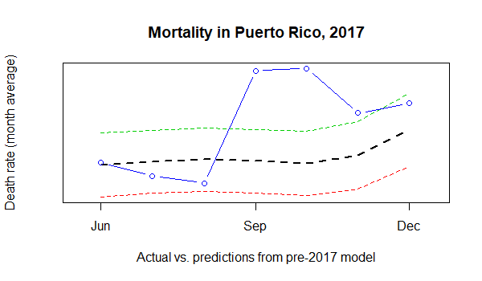

(Key point: RI does *not* say \(y_C\)s are similar pre- and post-Maria, only \(e_{\hat\theta}(y|r)\)s.)

## Residual ignorability applied to \(X\)es

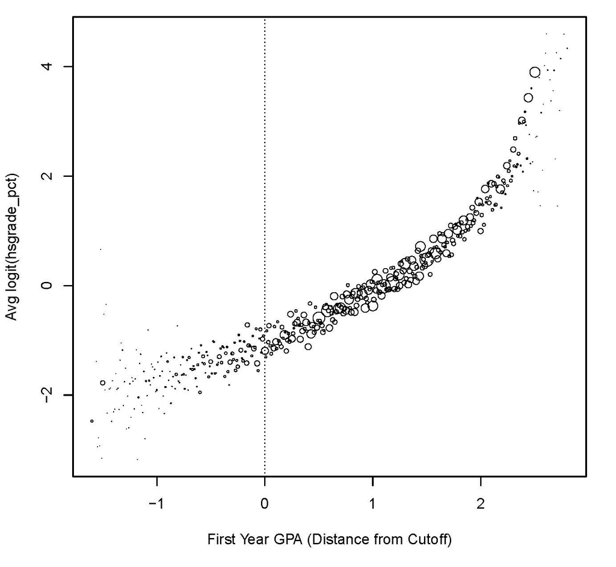

- Local randomization should be reflected in covariates, e.g. prior \(G\)rades (\(y\) axis).
- Due to trend, clear that \(G \not\perp Z (\equiv \mathcal{I}[R\leq 0])\). (\(G\) is not “balanced” vis a vis \(Z\).)
- Residual ignorability presupposes a trend model, e.g. \(G \approx \alpha_G + \beta_G R\), then asserts \(H': e_{(\alpha_G, \beta_G)}(G|R) \perp Z \vert \{R \in \mathcal{W}\}\). (\(G\)’s *residual* is balanced.)
- (In contrast, recent “local randomization” proposals say to get rid of data until \(\{R \in \mathcal{W}\}\), \(\mathcal{W}\) narrow enough that \(H: G \perp Z \vert \{R \in \mathcal{W}\}\) is not rejected.)

## Local randomization & density of \(R\)

### the McCrary (2008) test

- Purpose of test: expose whether subjects secured or avoided treatment by manipulating their \(R\)s.
- If so, then density of \(R\) differs on either side of cutpoint.
- Canadian colleges data have a clump at \(R=0\). McCrary throws a red flag!

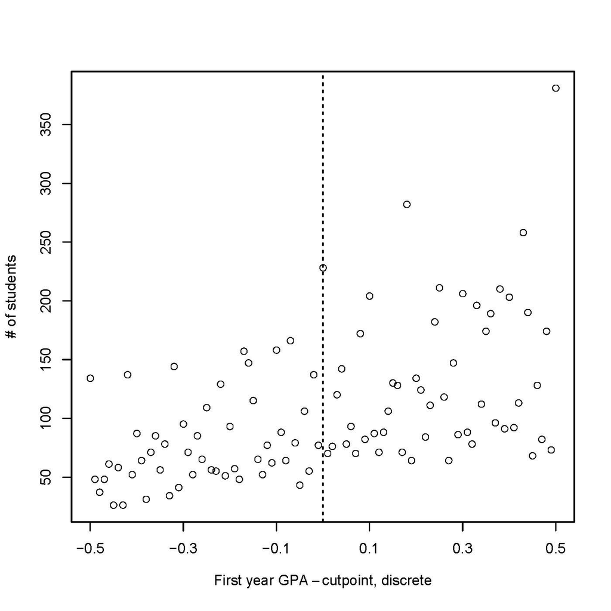

- To avoid rejecting \(\tilde{H}\), \(\mathcal{W} \mapsto \mathcal{W}\setminus \{0\}\) and \(\tilde{\mathcal{W}} \mapsto \tilde{\mathcal{W}}\setminus \{0\}\). (Carve hole in middle, leaving a “donut.”)

## Picking out a quasi-experiment within an RDD

> Q: I think I’m seeing naturally occurring random assignment in the vicinity of my regression discontinuity, but it’s hard to isolate the subjects whose assignment can be regarded as haphazard. Can methods help?

> A: To separate unwanted chaff from locally randomized wheat, the distinction must be marked with care. Probe “ignorability” of covariate residuals — not covariates themselves — and of the density of the running variable.

## Working your way around the donut

## Working your way around the donut

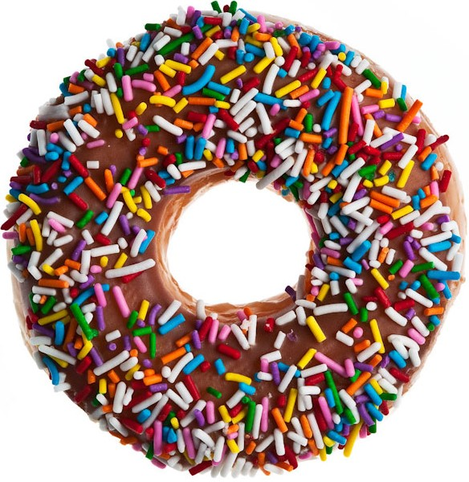

> Q: Getting rid of the sketchy part of my sample left me with a donut hole in the middle, right around the cutpoint. How does that help me to estimate the regression line’s limits as it approaches the cutpoint from above and from below?

> A: That hole in the middle only counts against limit interpretations of RDDs…

## Local randomization per S. & H., ii

*Notation*: \(e_\theta(\cdot| \cdot)\) denotes a *residual transformation*, typically \(e_{(a,b)}(y |r) = y - a -br\).

(If \((\hat\alpha, \hat\beta)\) come from fitting \(Y=\alpha + \beta R + \epsilon\), this \(e_{(\hat \alpha, \hat \beta)}(y_i | r_i)\) is a simple residual; but if \(Y=\alpha + \beta R + \tau Z+ \epsilon\) was fit, then \(e_{(\hat \alpha,\hat \beta)} (y_i | r_i)\) is the *partial* residual omitting \(Z\)s, \(y_i-\hat\alpha - \hat\beta r_i\).)

*Assumption: Ignorability of covariate residuals*. For given \(\hat{\theta}_x\), \(e_{\theta}(\cdot |\cdot)\), \[e_{\bar{\theta}_x} (X|R) \perp Z | \{R \in \mathcal{W}\},\, \text{where}\, \hat{\theta}_x \stackrel{P}{\rightarrow} \bar{\theta}_x.\]

*Assumption: Ignorability of potential outcome residuals*. For given \(\hat{\theta}_y\), \(e_\theta(\cdot |\cdot )\), \[e_{\bar{\theta}_y} (Y_C|R) \perp Z | \{R \in \mathcal{W}\}, \, \text{where}\, \hat{\theta}_y \stackrel{P}{\rightarrow} \bar{\theta}_y.\]

*Key advantages*. Identification of \(E[Y - Y_C| Z=1, R\in \mathcal{W}]\). \(\mathcal{W}\) doesn’t shrink as \(n\uparrow \infty\). Donuts allowed.

## Working our way around the donut

> Q: Getting rid of the sketchy part of my sample left me with a donut hole in the middle, right around the cutpoint. How does that help me to estimate the regression line’s limits as it approaches the cutpoint from above and from below?

> A: That hole in the middle only counts against limit-based interpretations of RDDs. Residual ignorability supports large-sample inference on differences of potential outcomes, as opposed to differences of limits of curves.

## Methods for limiting contamination sensitivity

## Methods for limiting contamination sensitivity

> Q: Tests and adjustments may have gotten rid of the better part of the sample that didn’t belong, but maybe they didn’t remove every last bit of contamination. Should we supplement our OLS estimates with a secondary analysis of sensitivity to this problem?

> A: The contamination issue must be addressed as a part of the *primary* analysis. It requires us to abandon OLS,…

## Sensitivity to clumps of bad data

Say there are “savvy” students who, when at risk for AP, “manipulate” grades \(\uparrow\). (Bribes?)  
This latent subgroup is overrepresented in excised donut hole \(\{i: z_i=0\}\), but may be elsewhere too. As many as \(O(n^{1/2})\) “bad” points remain, undercutting estimation of \(E(Y_C | R)\).

How does this affect \(\hat\tau\)? — A *contamination sensitivity* problem, if not recognized as such in RDD literature.

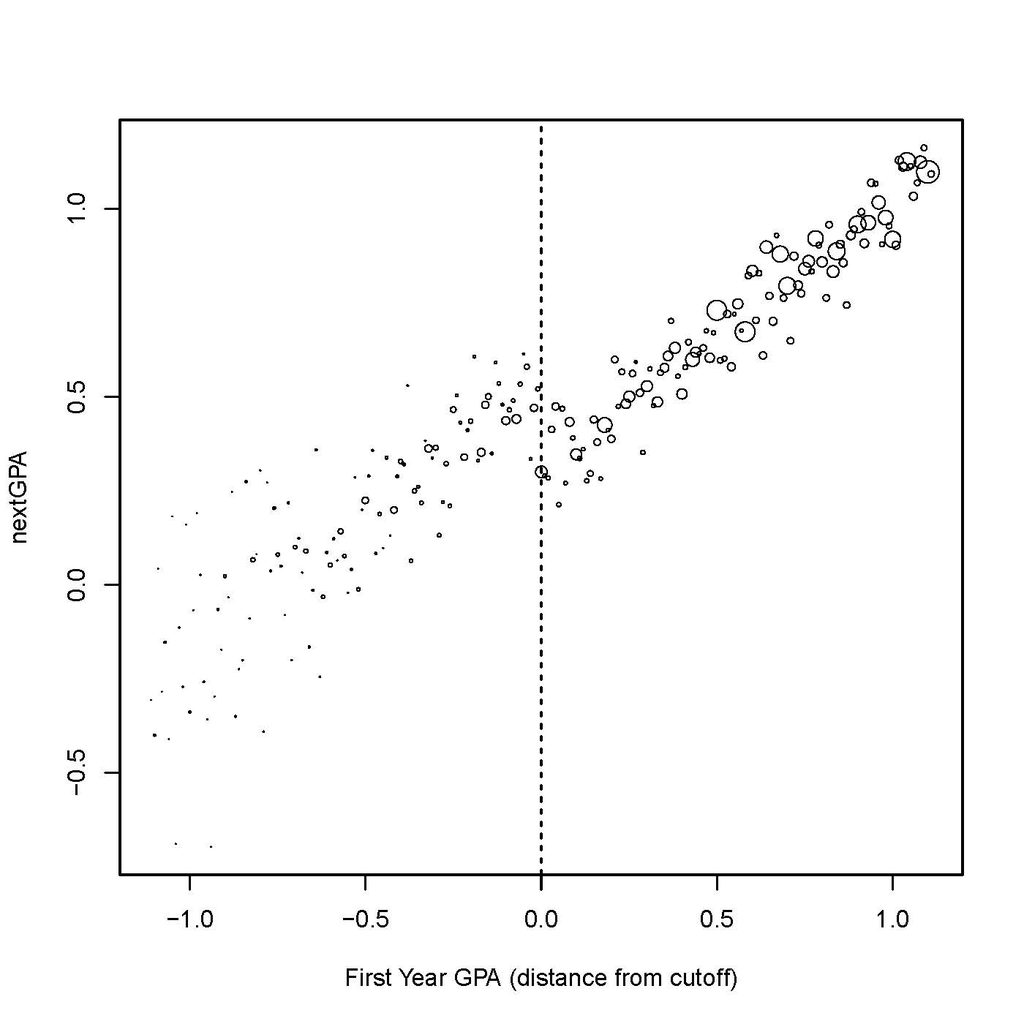

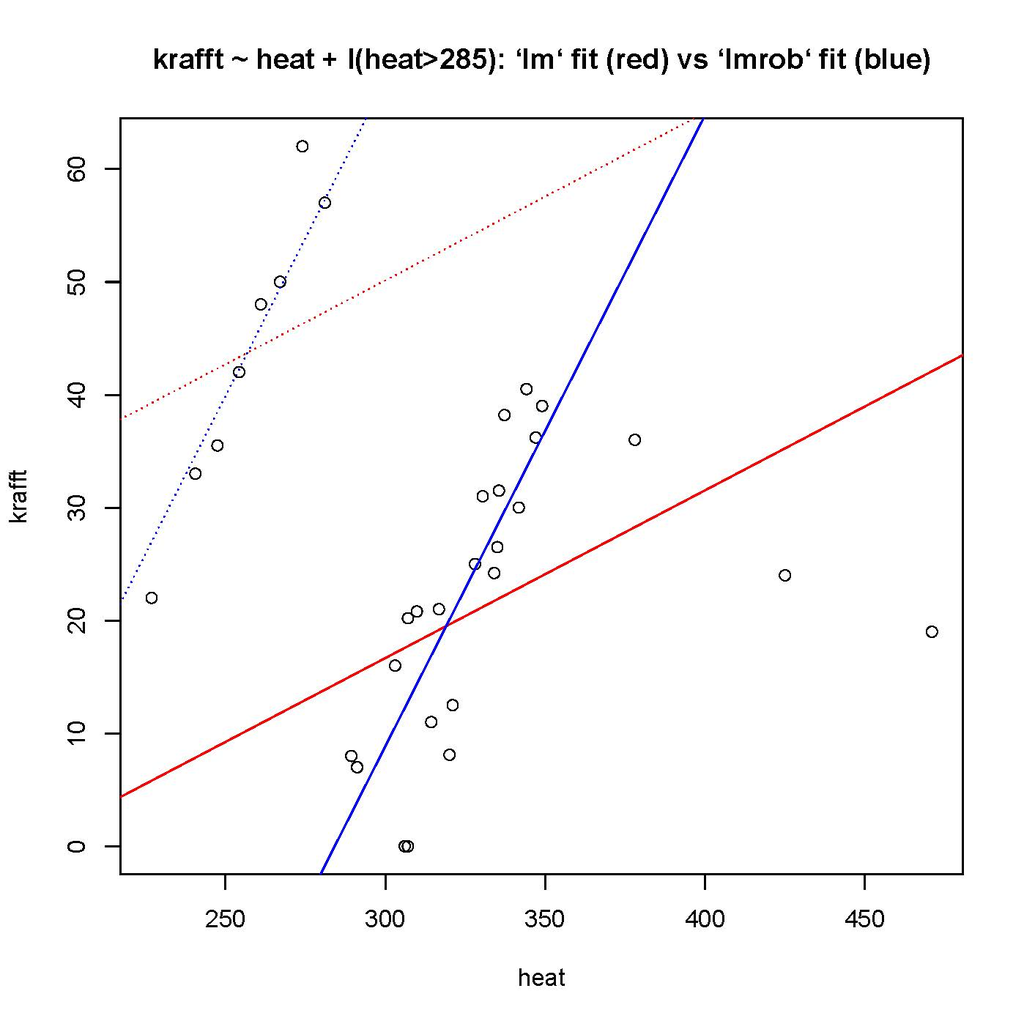

## Robust MM estimates of regression

### a high-level review

- Robust regression substitutes out OLS’ \(e_{(a,b)}(y|r) = y-a-br\) with \(e_{(a,b,s)}(y|r) = \psi\{(y - a -br)/s\}\), some \(\psi(\cdot)\), \(s(\cdot)\).
- After much study, robustness literature identified pairs \((\psi, s)\) that handle groups of outliers while retaining \(\sqrt{n}\) rates, efficiency.
- E.g., “MM with bisquare psi-function and robust scale”,…
- In R, `robustbase::lmrob`; in Stata, `mmregress`.
- To limit sensitivity to contamination of a \(O(n^{-1/2})\) share of the sample — the smallest contamination share you can expect specification testing to detect — OLS won’t do. Need robust MM regression (He 1991; Yohai and Zamar 1997).

## Methods for limiting contamination sensitivity

> Q: Tests and adjustments may have gotten rid of the better part of the sample that didn’t belong, but maybe they didn’t remove every last bit of contamination. Is there a sensitivity analysis method that addresses this issue?

> A: With RDDs, there’s a better option than post hoc sensitivity analysis. You can address sensitivity to contamination (as opposed to omitted variable sensitivity) as a part of the primary analysis, with the help of robust MM estimators. While less familiar in social science, these methods are efficient, easy to use and readily available in R and Stata.

## Are the answers any different?

## Are the answers any different?

> Q: Does bounded influence regression (following testing and adjustment of \(\mathcal{W}\)) give answers that are any different than RDD methods already in use?

> A: Sometimes yes, sometimes no….

## Data analysis

Academic probation and later GPA at the 3 Canadian colleges:

|  | Estimate | 95% CI | \(\mathcal{W}\) | n |
| --- | --- | --- | --- | --- |
| Local OLS | 0.23 | (0.19,0.28) | [0.01,1.24) | 26000 |
| Limitless | 0.24 | (0.17,0.31) | [0.01,0.50) | 10000 |
| Local Permutation | 0.11 | (0.05,0.17) | [0.01,0.18) | 3400 |

- Here limit-based Local OLS, Limitless tell similar stories. (If present, contamination was benign.)
- Here OLS’s CI narrower, due to its \(\mathcal{W}\) & \(n\) being larger. (Characteristic of this analysis, not these methods.)
- Local Permutation tells a different story. (Also suffers known bias…)

## Simulation: linear, well-spec.’d \(E(Y \vert R\))

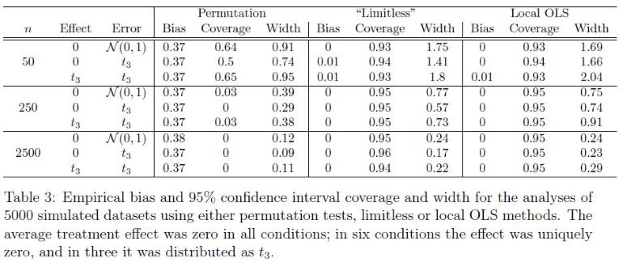

- Permutation (Cattaneo et al 2015) shows inadmissible bias, undercoverage.
- Limitless, Local OLS use a well-specified \(E(Y_C | R)\) model. They cover well, w/ little bias.
- Limitless’s CIs narrower with heavier-tailed effects (\(Y_{Ti}-Y_{Ci}\)) and/or errors (\(Y_i-E(Y | R)\)).

## Simulation: polynomial regression

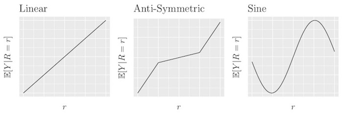

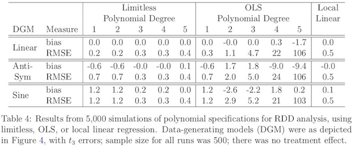

## Are the answers any different?

> Q: Does bounded influence regression (following testing and adjustment of \(\mathcal{W}\)) give answers that are any different than RDD methods already in use?

> A: Sometimes yes, sometimes no. Differences are more likely with heavy tailed errors, which give the robust method a heavy efficiency advantage. When differences occur, diagnostics show you why, and are likely to impugn the other method.

## Discussion

- In limit-based literature, main concern is with possibility that bandwidth/\(\mathcal{W}\) is too wide. (What about \(\mathcal{W}\)s that are too narrow, magnifying impact of contaminants?) To be “robust” to overly wide \(\mathcal{W}\), prominent limit-based methods use local polynomials — along w/ unbounded \(\rho(\cdot)\), non-robust \(s(\cdot)\).
- In the local randomization camp, recent methods narrow \(\mathcal{W}\) until \(H: X \perp Z| R\in \mathcal{W}\) is not rejected. Typically there is no allowance for \(Y\)–\(R\) association other than via \(Z=\mathcal{I}[R<0]\). (What about \(X\)s that are plainly tied up with \(R\)?)
- Both camps wind up reducing \(n\), if for different reasons. Contamination becomes harder to detect, and more difficult to compensate for.
- Our “Limitless” method avoids these traps.
- Furthermore, due to its use of robust M-estimation, it avoids OLS’s notorious instability with higher-order polynomials (Gelman and Imbens 2018).

## Appendix: robustness weights

- Robust regression fitting generates “robustness” weights \(\in [0,1]\), showing which observations the fitter deemed to be anomalous.
- If \(\mathcal{W}\) is still too wide, or its donut hole isn’t wide enough, plot of robustness weights against \(R\) gives an additional shot at detection.

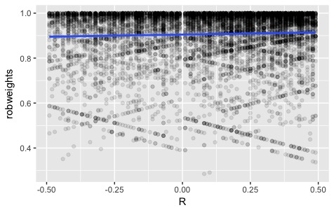

## References

Cattaneo, Matias D, Brigham R Frandsen, and Rocio Titiunik. 2015. “Randomization Inference in the Regression Discontinuity Design: An Application to Party Advantages in the US Senate.” *Journal of Causal Inference* 3 (1): 1–24.

Gelman, Andrew, and Guido W. Imbens. 2018. “Why High-Order Polynomials Should Not Be Used in Regression Discontinuity Designs.” *Journal of Business and Economic Statistics*.

Hahn, J., P. Todd, and W. Van der Klaauw. 2001. “Identification and Estimation of Treatment Effects with a Regression-Discontinuity Design.” *Econometrica* 69 (1): 201–9.

He, Xuming. 1991. “A Local Breakdown Property of Robust Tests in Linear Regression.” *Journal of Multivariate Analysis* 38 (2): 294–305.

Imbens, Guido W., and T. Lemieux. 2008. “Regression Discontinuity Designs: A Guide to Practice.” *Journal of Econometrics* 142 (2): 615–35.

Lee, David S. 2008. “Randomized Experiments from Non-Random Selection in Us House Elections.” *Journal of Econometrics* 142 (2): 675–97.

Lindo, J. M., N. J. Sanders, and P. Oreopoulos. 2010. “Ability, Gender, and Performance Standards: Evidence from Academic Probation.” *American Economic Journal: Applied Economics* 2 (2): 95–117.

Mattei, Alessandra, and Fabrizia Mealli. 2016. “Regression Discontinuity Designs as Local Randomized Experiments.” *Observational Studies* 2: 156–73.

McCrary, J. 2008. “Manipulation of the Running Variable in the Regression Discontinuity Design: A Density Test.” *Journal of Econometrics* 142 (2): 698–714.

Sales, Adam C., and Ben B. Hansen. 2019. “Limitless Regression Discontinuity.” 1403.5478. arxiv.org.

Thistlethwaite, D. L., and D. T. Campbell. 1960. “Regression-Discontinuity Analysis: An Alternative to the Ex Post Facto Experiment.” *Journal of Educational Psychology* 51 (6): 309.

Yohai, Vı́ctor J, and Ruben H Zamar. 1997. “Optimal Locally Robust M-Estimates of Regression.” *Journal of Statistical Planning and Inference* 64 (2): 309–23.